# Step 2: PacBio HiFi Quality Filtering

# 1 Introduction

## 1.1 Purpose

This notebook is **Step 2** of the PacBio HiFi full-length 16S rRNA workflow. It reads the validated, sample-named FASTQ files generated by Step 1, implements PacBio-style read statistics and Q20 filtering in R, and creates an auditable QC report before Step 3 (Primer Trimming with Cutadapt). After primer trimming, Step 4 supports `maxEE` selection and Step 5 performs the complete DADA2 analysis.

PacBio HiFi reads already span the full amplified 16S region. This notebook therefore assesses complete-read length, GC content, and quality value (QV) and does not choose a positional truncation length. Reads below the configurable Q20 threshold are excluded from the filtered FASTQs used by subsequent steps.

## 1.2 Prerequisites

Before running this notebook:

- Complete Step 1 successfully.
- Confirm that mapped_fastq/ contains the validated sample FASTQs.
- Confirm that data_integrity_and_sample_mapping.xlsx contains the `Sample_Manifest` worksheet.
- Install the R dependencies used by the workflow.

## 1.3 What This Notebook Does

1. **Reads the Step 1 manifest** and reconstructs portable paths to the validated FASTQ files.
2. **Streams every FASTQ** in fixed-size chunks.
3. **Calculates read statistics**, including read length, GC percentage, and quality value (QV) derived from mean base-error probability.
4. **Applies a quality threshold of Q20**, writing passing records to new filtered FASTQ files
5. **Adds the complete per-read audit table to Excel** and retains a bounded plotting sample so large runs remain memory efficient.
6. **Creates pre-filter read-length and QV distributions** as inline figures and standalone PDFs.
7. **Exports a documented Excel workbook** with run settings, pre/post-filter sample QC, and a Column Dictionary.

## 1.4 Expected Input

- results/1_data_integrity_and_sample_mapping/data_integrity_and_sample_mapping.xlsx
- results/1_data_integrity_and_sample_mapping/mapped_fastq/

## 1.5 Expected Output

- results/2_quality_filtered_reads/quality_and_read_length_summary.xlsx
- results/2_quality_filtered_reads/Q20_filtered_fastq/
- results/2_quality_filtered_reads/read_length_distribution.pdf
- results/2_quality_filtered_reads/read_quality_distribution.pdf

# 2 Environment Setup

## 2.1 Load Required Packages

Load the packages used for streaming FASTQ files, building plots and tables, reading the Step 1 manifest, and writing documented Excel results. The shared helper functions are sourced from R/functions/.

```r
# Declare dependencies in one place so the notebook fails before reading or
# writing files when the environment is incomplete.
required_packages <- c(
  "data.table", "DT", "fs", "ggplot2", "here", "knitr",
  "openxlsx", "readxl", "ShortRead"
)

missing_packages <- required_packages[
  !vapply(required_packages, requireNamespace, quietly = TRUE, FUN.VALUE = logical(1))
]

if (length(missing_packages) > 0L) {
  stop(
    "Missing required package(s): ", paste(missing_packages, collapse = ", "),
    ". Install them before running Notebook 2."
  )
}

# Attach packages used repeatedly; less frequent calls remain namespace-qualified.
library(data.table)
library(fs)
library(ggplot2)
library(here)

# Reuse the same workbook and portable-link behavior as Notebook 1.
source(here("R", "functions", "add_sheet_to_excel_function.R"))
source(here("R", "functions", "build_column_dictionary_function.R"))
source(here("R", "functions", "render_output_links_function.R"))
source(here("R", "functions", "render_output_tree_function.R"))
```

# 3 Configuration

## 3.1 Define Input and Output Paths

Define all paths relative to the project root. The Step 1 workbook supplies sample identities, while the FASTQ basenames are resolved inside the current project so copied projects remain portable.

```r
# Step 1 inputs used by this notebook.
step1_folder <- here("results", "1_data_integrity_and_sample_mapping")
step1_workbook <- here(step1_folder, "data_integrity_and_sample_mapping.xlsx")
mapped_fastq_folder <- here(step1_folder, "mapped_fastq")

# Step 2 owns this complete output subtree.
results_folder <- here("results", "2_quality_filtered_reads")
filtered_fastq_folder <- here(results_folder, "Q20_filtered_fastq")
# The per-read table is streamed through a temporary TSV to keep memory bounded,
# imported into Excel, and deleted before the notebook finishes.
read_statistics_path <- tempfile(pattern = "step2_per_read_", fileext = ".tsv")
workbook_path <- here(results_folder, "quality_and_read_length_summary.xlsx")
length_plot_path <- here(results_folder, "read_length_distribution.pdf")
quality_plot_path <- here(results_folder, "read_quality_distribution.pdf")
```

## 3.2 Define QC Parameters

Set transparent review thresholds and streaming limits. The expected length range should match the primer pair and biological target; it is used only for visualization and does not filter reads!

```r
# Full-length bacterial 16S amplicons are commonly near 1.5 kb. These broad
# review bounds can be adjusted for another primer pair or target region.
expected_length_min <- 1200L
expected_length_max <- 1800L

# Match the user-adjustable QV filter in PacBio's HiFi-16S workflow. QV is
# calculated from the mean base-error probability, as documented by SeqKit.
read_qv_cutoff <- 20

# Read FASTQ records in bounded chunks and keep at most this many observations
# per sample for plots and approximate distribution quantiles.
stream_yield_size <- 10000L
maximum_plot_reads_per_sample <- 50000L

# Phred+33 is the standard FASTQ quality encoding used for these files.
quality_ascii_offset <- 33L
```

## 3.3 Validate Configuration

Validate inputs and parameter relationships before creating or replacing any Step 2 output.

```r
# Fail early when Step 1 artifacts are missing.
if (!file_exists(step1_workbook)) {
  stop("Step 1 workbook does not exist: ", step1_workbook)
}
if (!dir_exists(mapped_fastq_folder)) {
  stop("Step 1 mapped FASTQ folder does not exist: ", mapped_fastq_folder)
}

# Prevent invalid thresholds or non-positive streaming limits.
if (expected_length_min < 1L || expected_length_max <= expected_length_min) {
  stop("Expected read-length bounds must satisfy 1 <= minimum < maximum.")
}
if (stream_yield_size < 1L || maximum_plot_reads_per_sample < 1L) {
  stop("Streaming and plotting limits must be positive integers.")
}

# Create only this notebook's managed output folders.
dir_create(results_folder, recurse = TRUE)
dir_create(filtered_fastq_folder, recurse = TRUE)
```

```
## Step 1 workbook: /Users/jon/Documents/DADA2_16S_PacBio_HiFi_Workflow/results/1_data_integrity_and_sample_mapping/data_integrity_and_sample_mapping.xlsx
```

```
## Mapped FASTQ folder: /Users/jon/Documents/DADA2_16S_PacBio_HiFi_Workflow/results/1_data_integrity_and_sample_mapping/mapped_fastq
```

```
## Step 2 results folder: /Users/jon/Documents/DADA2_16S_PacBio_HiFi_Workflow/results/2_quality_filtered_reads
```

```
## Expected read-length range: 1200 to 1800 bp
```

```
## Per-read QV filtering cutoff: Q20
```

# 4 Functions

## 4.1 Define Table and FASTQ Helpers

Define the shared presentation behavior and a streaming FASTQ summarizer. Comments describe the memory bounds, quality conversion, and distinction between full-dataset summaries and bounded plotting samples.

```r
render_table <- function(x, caption = NULL, column_widths = NULL) {
  # Use one normalized data.frame for both HTML and GitHub renderers.
  table_data <- as.data.frame(x)

  if (knitr::is_html_output()) {
    # Force every column left and optionally widen selected columns. DataTables
    # uses zero-based targets, so subtract one from R column positions.
    column_definitions <- list(list(className = "dt-left", targets = "_all"))
    if (!is.null(column_widths)) {
      width_columns <- which(!is.na(column_widths) & nzchar(column_widths))
      column_definitions <- c(
        column_definitions,
        lapply(width_columns, function(column_index) {
          list(targets = column_index - 1L, width = column_widths[[column_index]])
        })
      )
    }

    # These are inspection tables: retain scrolling but remove sorting, search,
    # pagination, and entry-count controls.
    DT::datatable(
      table_data,
      caption = caption,
      rownames = FALSE,
      class = "display compact",
      options = list(
        scrollX = TRUE,
        scrollY = "400px",
        scrollCollapse = TRUE,
        paging = FALSE,
        searching = FALSE,
        ordering = FALSE,
        info = FALSE,
        dom = "t",
        autoWidth = !is.null(column_widths),
        columnDefs = column_definitions
      )
    )
  } else {
    # GitHub receives a portable, fully left-aligned Markdown table.
    knitr::kable(
      table_data,
      caption = caption,
      row.names = FALSE,
      align = rep("l", ncol(table_data))
    )
  }
}

calculate_read_qv <- function(quality_strings) {
  # SeqKit defines average read quality by converting every base Q score to an
  # error probability, averaging those probabilities, and converting the mean
  # error probability back to Phred scale. This is deliberately not the
  # arithmetic mean of the base Q scores.
  vapply(
    quality_strings,
    function(quality_string) {
      base_q <- utf8ToInt(quality_string) - quality_ascii_offset
      -10 * log10(mean(10^(-base_q / 10)))
    },
    numeric(1)
  )
}

summarize_fastq <- function(path, sample_id, filtered_path, statistics_connection) {
  # Stream a fixed number of records per yield so memory use is independent of
  # total FASTQ size. The streamer is always closed, including after an error.
  streamer <- ShortRead::FastqStreamer(path, n = stream_yield_size)
  on.exit(close(streamer), add = TRUE)

  total_reads <- 0L
  total_bases <- 0
  total_length_squared <- 0
  minimum_length <- Inf
  maximum_length <- -Inf
  reads_in_expected_range <- 0L
  total_read_qv <- 0
  total_read_qv_squared <- 0
  minimum_read_qv <- Inf
  maximum_read_qv <- -Inf
  total_gc_percent <- 0
  reads_with_defined_gc <- 0L
  passing_reads <- 0L
  passing_bases <- 0

  # Plot vectors are intentionally capped. Full-dataset means, ranges, counts,
  # and standard deviations continue to use every streamed read.
  plot_lengths <- numeric(0)
  plot_read_qv <- numeric(0)

  # Remove a prior filtered file before the first append. Step 1 inputs remain
  # read-only and can therefore always be used to reproduce the filtering.
  if (file_exists(filtered_path)) file_delete(filtered_path)

  repeat {
    fastq_chunk <- ShortRead::yield(streamer)
    if (length(fastq_chunk) == 0L) break

    sequences <- ShortRead::sread(fastq_chunk)
    read_lengths <- as.numeric(Biostrings::width(sequences))
    # ShortRead stores qualities as a FastqQuality wrapper around a BStringSet.
    # Access the documented S4 slots directly because quality() is a generic
    # attached by ShortRead but is not exported for namespace-qualified use.
    quality_strings <- as.character(slot(slot(fastq_chunk, "quality"), "quality"))
    read_qv <- calculate_read_qv(quality_strings)

    # SeqKit reports GC as (G+C)/(A+C+G+T), excluding ambiguous characters
    # from the denominator. Reads without canonical bases receive NA.
    base_counts <- Biostrings::letterFrequency(sequences, letters = c("A", "C", "G", "T"))
    canonical_bases <- rowSums(base_counts)
    gc_percent <- fifelse(
      canonical_bases > 0,
      100 * (base_counts[, "C"] + base_counts[, "G"]) / canonical_bases,
      NA_real_
    )
    pass_qv <- read_qv >= read_qv_cutoff

    chunk_reads <- length(read_lengths)
    total_reads <- total_reads + chunk_reads
    total_bases <- total_bases + sum(read_lengths)
    total_length_squared <- total_length_squared + sum(read_lengths^2)
    minimum_length <- min(minimum_length, min(read_lengths))
    maximum_length <- max(maximum_length, max(read_lengths))
    reads_in_expected_range <- reads_in_expected_range + sum(
      read_lengths >= expected_length_min & read_lengths <= expected_length_max
    )

    total_read_qv <- total_read_qv + sum(read_qv)
    total_read_qv_squared <- total_read_qv_squared + sum(read_qv^2)
    minimum_read_qv <- min(minimum_read_qv, min(read_qv))
    maximum_read_qv <- max(maximum_read_qv, max(read_qv))
    total_gc_percent <- total_gc_percent + sum(gc_percent, na.rm = TRUE)
    reads_with_defined_gc <- reads_with_defined_gc + sum(!is.na(gc_percent))
    passing_reads <- passing_reads + sum(pass_qv)
    passing_bases <- passing_bases + sum(read_lengths[pass_qv])

    # Write every per-read statistic to the uncompressed audit table. The table
    # mirrors the SeqKit fx2tab fields used by PacBio while remaining R-native.
    read_statistics <- data.table(
      SampleID = sample_id,
      ReadID = as.character(ShortRead::id(fastq_chunk)),
      ReadLength = read_lengths,
      GCPercent = round(gc_percent, 4),
      ReadQV = round(read_qv, 4),
      PassQVFilter = pass_qv
    )
    writeLines(
      apply(read_statistics, 1L, paste, collapse = "\t"),
      con = statistics_connection
    )

    # Append only QV-passing records to a new uncompressed FASTQ. An empty output is
    # still created below when no read passes, preserving one output per input.
    if (any(pass_qv)) {
      ShortRead::writeFastq(
        fastq_chunk[pass_qv],
        filtered_path,
        mode = "a",
        compress = FALSE
      )
    }

    # Retain the earliest bounded observations deterministically. Repeated runs
    # therefore generate identical plots from identical input files.
    remaining_plot_slots <- maximum_plot_reads_per_sample - length(plot_lengths)
    if (remaining_plot_slots > 0L) {
      keep <- seq_len(min(chunk_reads, remaining_plot_slots))
      plot_lengths <- c(plot_lengths, read_lengths[keep])
      plot_read_qv <- c(plot_read_qv, read_qv[keep])
    }
  }

  if (total_reads == 0L) stop("FASTQ contains no reads: ", path)

  # Preserve a one-output-per-input contract even when no read reaches Q20.
  if (!file_exists(filtered_path)) {
    empty_filtered_connection <- file(filtered_path, open = "wb")
    close(empty_filtered_connection)
  }

  # Compute full-dataset means and sample standard deviations from accumulated
  # sums, avoiding storage of every observation.
  mean_length <- total_bases / total_reads
  length_variance <- if (total_reads > 1L) {
    (total_length_squared - total_reads * mean_length^2) / (total_reads - 1L)
  } else {
    0
  }
  mean_read_qv <- total_read_qv / total_reads
  quality_variance <- if (total_reads > 1L) {
    (total_read_qv_squared - total_reads * mean_read_qv^2) / (total_reads - 1L)
  } else {
    0
  }

  # Quantiles are calculated from the documented bounded plotting sample. This
  # is exact whenever total_reads does not exceed maximum_plot_reads_per_sample.
  length_quantiles <- stats::quantile(
    plot_lengths,
    probs = c(0.05, 0.25, 0.50, 0.75, 0.95),
    names = FALSE,
    type = 7
  )

  list(
    summary = data.table(
      SampleID = sample_id,
      FASTQ = as.character(path),
      TotalReads = as.numeric(total_reads),
      TotalBases = as.numeric(total_bases),
      MinimumLength = as.numeric(minimum_length),
      MeanLength = round(mean_length, 1),
      LengthSD = round(sqrt(max(length_variance, 0)), 1),
      MaximumLength = as.numeric(maximum_length),
      LengthP05 = round(length_quantiles[[1]], 1),
      LengthP25 = round(length_quantiles[[2]], 1),
      MedianLength = round(length_quantiles[[3]], 1),
      LengthP75 = round(length_quantiles[[4]], 1),
      LengthP95 = round(length_quantiles[[5]], 1),
      ReadsInExpectedLengthRange = as.numeric(reads_in_expected_range),
      PercentInExpectedLengthRange = round(100 * reads_in_expected_range / total_reads, 2),
      MeanGCPercent = if (reads_with_defined_gc > 0L) {
        round(total_gc_percent / reads_with_defined_gc, 2)
      } else {
        NA_real_
      },
      MinimumReadQV = round(minimum_read_qv, 2),
      MeanReadQV = round(mean_read_qv, 2),
      ReadQVSD = round(sqrt(max(quality_variance, 0)), 2),
      MaximumReadQV = round(maximum_read_qv, 2),
      QVCutoff = as.numeric(read_qv_cutoff),
      PassingReads = as.numeric(passing_reads),
      FilteredReads = as.numeric(total_reads - passing_reads),
      PercentPassingQV = round(100 * passing_reads / total_reads, 2),
      PassingBases = as.numeric(passing_bases),
      FilteredFASTQ = as.character(filtered_path),
      PlotReads = as.numeric(length(plot_lengths))
    ),
    plot_data = data.table(
      SampleID = sample_id,
      ReadLength = plot_lengths,
      ReadQV = plot_read_qv
    )
  )
}
```

# 5 Step 1 Manifest

## 5.1 Read and Validate the Sample Manifest

Read sample identities from the Step 1 audit workbook rather than inferring them again from filenames. Reconstruct each FASTQ path inside the current project and validate the one-row-per-sample relationship.

```r
# Read only the fields required for QC and path reconstruction.
manifest_raw <- readxl::read_excel(
  step1_workbook,
  sheet = "Sample_Manifest",
  col_types = "text"
)
manifest_raw <- as.data.table(manifest_raw)

required_manifest_columns <- c("PoolNumber", "SampleID", "MappedFASTQ", "IntegrityStatus")
missing_manifest_columns <- setdiff(required_manifest_columns, names(manifest_raw))
if (length(missing_manifest_columns) > 0L) {
  stop("Step 1 Sample_Manifest is missing: ", paste(missing_manifest_columns, collapse = ", "))
}

# Refuse QC input from a Step 1 row that did not pass integrity validation.
if (any(manifest_raw$IntegrityStatus != "PASS")) {
  stop("Every Step 1 Sample_Manifest row must have IntegrityStatus = PASS.")
}

sample_manifest <- manifest_raw[, .(
  PoolNumber = as.integer(PoolNumber),
  SampleID = as.character(SampleID),
  FASTQ = as.character(path(mapped_fastq_folder, path_file(MappedFASTQ)))
)]
setorder(sample_manifest, PoolNumber, SampleID)

if (nrow(sample_manifest) == 0L) stop("Step 1 Sample_Manifest contains no samples.")
if (anyDuplicated(sample_manifest$SampleID)) stop("Step 1 Sample_Manifest contains duplicate SampleIDs.")
if (any(!file_exists(sample_manifest$FASTQ))) {
  stop(
    "Mapped FASTQ file(s) are missing: ",
    paste(sample_manifest[!file_exists(FASTQ), FASTQ], collapse = ", ")
  )
}

render_table(
  sample_manifest,
  "Validated Step 1 inputs for PacBio QC",
  column_widths = c("120px", "190px", "520px")
)
```

| PoolNumber | SampleID | FASTQ |
| --- | --- | --- |
| 1 | Sample01 | /Users/jon/Documents/DADA2_16S_PacBio_HiFi_Workflow/results/1_data_integrity_and_sample_mapping/mapped_fastq/Sample01.fastq |
| 1 | Sample02 | /Users/jon/Documents/DADA2_16S_PacBio_HiFi_Workflow/results/1_data_integrity_and_sample_mapping/mapped_fastq/Sample02.fastq |
| 1 | Sample03 | /Users/jon/Documents/DADA2_16S_PacBio_HiFi_Workflow/results/1_data_integrity_and_sample_mapping/mapped_fastq/Sample03.fastq |
| 2 | Sample04 | /Users/jon/Documents/DADA2_16S_PacBio_HiFi_Workflow/results/1_data_integrity_and_sample_mapping/mapped_fastq/Sample04.fastq |
| 2 | Sample05 | /Users/jon/Documents/DADA2_16S_PacBio_HiFi_Workflow/results/1_data_integrity_and_sample_mapping/mapped_fastq/Sample05.fastq |
| 2 | Sample06 | /Users/jon/Documents/DADA2_16S_PacBio_HiFi_Workflow/results/1_data_integrity_and_sample_mapping/mapped_fastq/Sample06.fastq |

This status line confirms how many Step 1 samples have valid, uniquely resolved FASTQ inputs for quality assessment.

```
## Validated FASTQ inputs: 6
```

# 6 FASTQ Quality Assessment

## 6.1 Stream and Summarize FASTQ Files

Stream every validated FASTQ, calculate full-dataset statistics, and write reads meeting the configured QV threshold to new FASTQ files.

```r
# Rebuild the uncompressed per-read audit table on every run and write the header
# once. A single open connection permits memory-bounded chunk-by-chunk output.
if (file_exists(read_statistics_path)) file_delete(read_statistics_path)

# This notebook owns Q20_filtered_fastq/. Remove FASTQs from an earlier sample
# naming scheme before writing the current dataset so obsolete identifiers
# cannot coexist with the newly generated workflow inputs.
stale_filtered_fastq <- dir_ls(
  filtered_fastq_folder,
  regexp = "\\.(fastq|fq)$",
  type = "file",
  recurse = FALSE
)
if (length(stale_filtered_fastq) > 0L) file_delete(stale_filtered_fastq)

statistics_connection <- file(read_statistics_path, open = "wt")
writeLines(
  paste(c("SampleID", "ReadID", "ReadLength", "GCPercent", "ReadQV", "PassQVFilter"), collapse = "\t"),
  statistics_connection
)

# Keep the connection safe on errors and close it normally after all samples.
qc_results <- tryCatch(
  lapply(seq_len(nrow(sample_manifest)), function(i) {
    filtered_path <- path(
      filtered_fastq_folder,
      paste0(sample_manifest$SampleID[[i]], "_filtered_Q", read_qv_cutoff, ".fastq")
    )
    summarize_fastq(
      path = sample_manifest$FASTQ[[i]],
      sample_id = sample_manifest$SampleID[[i]],
      filtered_path = filtered_path,
      statistics_connection = statistics_connection
    )
  }),
  finally = close(statistics_connection)
)

sample_qc <- rbindlist(lapply(qc_results, `[[`, "summary"), use.names = TRUE)
plot_data <- rbindlist(lapply(qc_results, `[[`, "plot_data"), use.names = TRUE)

# Restore pool metadata and deterministic sample order after streaming.
sample_qc <- merge(
  sample_manifest[, .(PoolNumber, SampleID)],
  sample_qc,
  by = "SampleID",
  all.x = TRUE,
  sort = FALSE
)
setorder(sample_qc, PoolNumber, SampleID)
plot_data[, SampleID := factor(SampleID, levels = sample_qc$SampleID)]

# Confirm that each sample retained reads at Q20 and assess the broad expected
# length interval independently. Filtering is per read, not based on a sample's
# mean QV.
sample_qc[, QualityStatus := fifelse(
  PassingReads > 0,
  "PASS",
  "REVIEW: no reads passed the configured QV cutoff"
)]
sample_qc[, LengthStatus := fifelse(
  PercentInExpectedLengthRange >= 50,
  "PASS",
  "REVIEW: fewer than 50% of reads inside expected range"
)]
sample_qc[, OverallQCStatus := fifelse(
  QualityStatus == "PASS" & LengthStatus == "PASS",
  "PASS",
  "REVIEW"
)]
```

The report now confirms how many FASTQs were processed and how many reproducibly sampled observations are available for the distribution plots.

```
## FASTQ files summarized: 6
```

```
## Reads retained for plotting: 5845
```

## 6.2 Sample QC Summary

Display the primary per-sample QC metrics.

```r
render_table(
  sample_qc[, .(
    PoolNumber,
    SampleID,
    TotalReads,
    MeanLength,
    MedianLength,
    MeanGCPercent,
    PercentInExpectedLengthRange,
    MeanReadQV,
    PassingReads,
    FilteredReads,
    PercentPassingQV,
    QualityStatus,
    LengthStatus,
    OverallQCStatus
  )],
  "PacBio HiFi sample quality summary",
  column_widths = c("80px", "140px", rep(NA_character_, 12))
)
```

| PoolNumber | SampleID | TotalReads | MeanLength | MedianLength | MeanGCPercent | PercentInExpectedLengthRange | MeanReadQV | PassingReads | FilteredReads | PercentPassingQV | QualityStatus | LengthStatus | OverallQCStatus |
| --- | --- | --- | --- | --- | --- | --- | --- | --- | --- | --- | --- | --- | --- |
| 1 | Sample01 | 1100 | 1497.3 | 1494 | 51.98 | 99.82 | 45.95 | 1100 | 0 | 100 | PASS | PASS | PASS |
| 1 | Sample02 | 1560 | 1498.6 | 1492 | 52.82 | 99.55 | 57.33 | 1560 | 0 | 100 | PASS | PASS | PASS |
| 1 | Sample03 | 1608 | 1496.7 | 1492 | 52.61 | 99.94 | 60 | 1608 | 0 | 100 | PASS | PASS | PASS |
| 2 | Sample04 | 530 | 1495.7 | 1492 | 54 | 99.43 | 56.88 | 530 | 0 | 100 | PASS | PASS | PASS |
| 2 | Sample05 | 481 | 1489.3 | 1490 | 54.33 | 100 | 62.33 | 481 | 0 | 100 | PASS | PASS | PASS |
| 2 | Sample06 | 566 | 1488.3 | 1489 | 52.96 | 100 | 58.35 | 566 | 0 | 100 | PASS | PASS | PASS |

## 6.3 Read-Length Distribution

Plot the bounded read-length sample for each biological sample. Dashed vertical lines mark the configured expected range; they are merely visualization guides, not filtering boundaries!

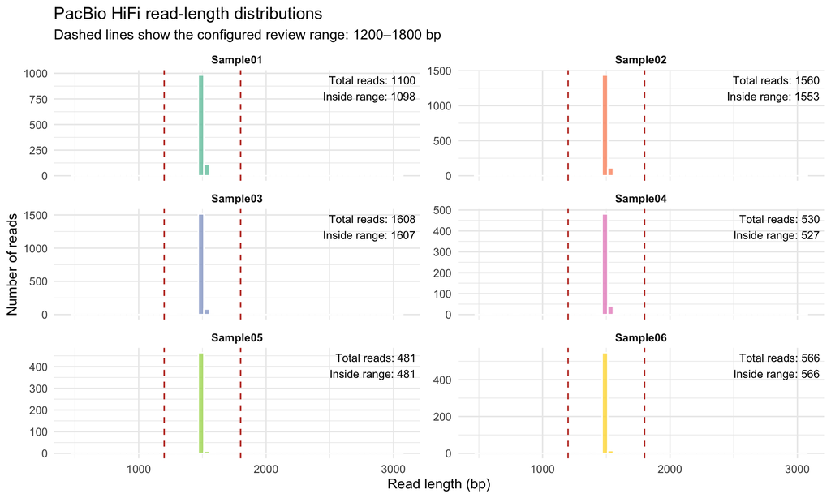

```r
length_plot <- ggplot(plot_data, aes(x = ReadLength, fill = SampleID)) +
  geom_histogram(bins = 60, alpha = 0.75, color = "white") +
  geom_vline(
    xintercept = c(expected_length_min, expected_length_max),
    linetype = "dashed",
    color = "#C0392B",
    linewidth = 0.6
  ) +
  geom_text(
    data = sample_qc,
    aes(
      x = Inf,
      y = Inf,
      label = paste0(
        "Total reads: ", TotalReads,
        "\nInside range: ", ReadsInExpectedLengthRange
      )
    ),
    inherit.aes = FALSE,
    hjust = 1.05,
    vjust = 1.25,
    size = 3.4
  ) +
  facet_wrap(~ SampleID, scales = "free_y", ncol = 2) +
  scale_fill_brewer(palette = "Set2", guide = "none") +
  labs(
    title = "PacBio HiFi read-length distributions",
    subtitle = paste0(
      "Dashed lines show the configured review range: ",
      expected_length_min, "–", expected_length_max, " bp"
    ),
    x = "Read length (bp)",
    y = "Number of reads"
  ) +
  theme_minimal(base_size = 12) +
  theme(strip.text = element_text(face = "bold"))

print(length_plot)
```

The read-length distribution displayed above is also saved as a standalone PDF, and its path is reported below.

```
## Read-length plot saved to: /Users/jon/Documents/DADA2_16S_PacBio_HiFi_Workflow/results/2_quality_filtered_reads/read_length_distribution.pdf
```

## 6.4 Read-QV Distribution

Plot the read-quality distribution calculated from each read’s mean base-error probability. The dashed line is the active Q20 filtering threshold!

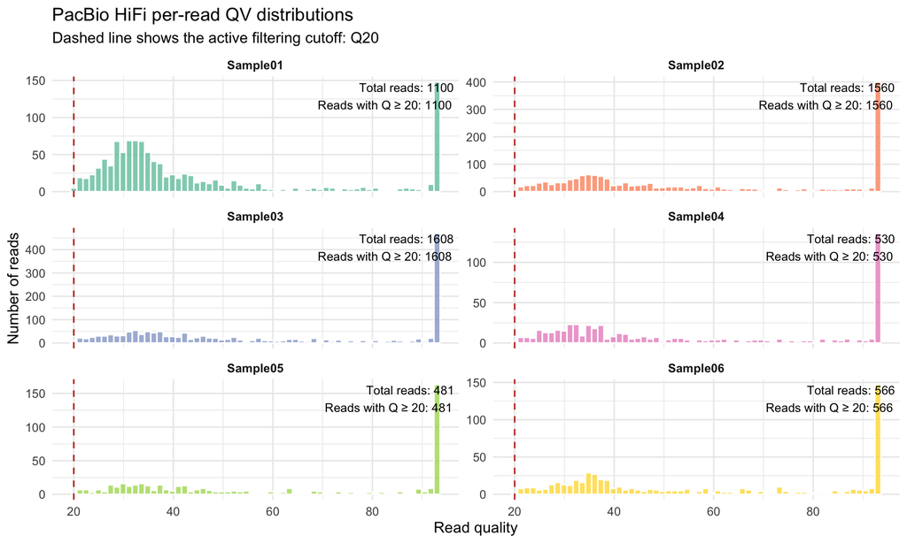

```r
quality_plot <- ggplot(plot_data, aes(x = ReadQV, fill = SampleID)) +
  geom_histogram(bins = 60, alpha = 0.75, color = "white") +
  geom_vline(
    xintercept = read_qv_cutoff,
    linetype = "dashed",
    color = "#C0392B",
    linewidth = 0.6
  ) +
  geom_text(
    data = sample_qc,
    aes(
      x = Inf,
      y = Inf,
      label = paste0(
        "Total reads: ", TotalReads,
        "\nReads with Q ≥ ", QVCutoff, ": ", PassingReads
      )
    ),
    inherit.aes = FALSE,
    hjust = 1.05,
    vjust = 1.25,
    size = 3.4
  ) +
  facet_wrap(~ SampleID, scales = "free_y", ncol = 2) +
  scale_fill_brewer(palette = "Set2", guide = "none") +
  labs(
    title = "PacBio HiFi per-read QV distributions",
    subtitle = paste0(
      "Dashed line shows the active filtering cutoff: Q",
      read_qv_cutoff
    ),
    x = "Read quality",
    y = "Number of reads"
  ) +
  theme_minimal(base_size = 12) +
  theme(strip.text = element_text(face = "bold"))

print(quality_plot)
```

The read-quality distribution displayed above is saved as a standalone PDF for sharing and comparison outside the notebook.

```
## Read-QV plot saved to: /Users/jon/Documents/DADA2_16S_PacBio_HiFi_Workflow/results/2_quality_filtered_reads/read_quality_distribution.pdf
```

# 7 Export Results

## 7.1 Save QC Tables to Excel

Create a typed run summary and a complete per-sample QC table, write both with the shared add_sheet_to_excel_function.R helper, and document every exported column with build_column_dictionary_function.R.

The report prints the completed workbook path after all result sheets, column definitions, and header comments have been written.

```
## QC workbook written to: /Users/jon/Documents/DADA2_16S_PacBio_HiFi_Workflow/results/2_quality_filtered_reads/quality_and_read_length_summary.xlsx
```

## 7.2 Final QC Decision

Confirm that every input produced a complete summary and every required output file exists. A `REVIEW` status is not a processing failure because the thresholds are descriptive review rules rather than filters.

```r
# Structural completion is required even when one or more biological samples
# are flagged for review.
qc_complete <-
  nrow(sample_qc) == nrow(sample_manifest) &&
  all(sample_qc$TotalReads > 0) &&
  all(file_exists(sample_qc$FilteredFASTQ)) &&
  file_exists(workbook_path) &&
  file_exists(length_plot_path) &&
  file_exists(quality_plot_path)

if (!qc_complete) {
  stop("Step 2 QC outputs are incomplete. Review the preceding diagnostics.")
}
```

After structural validation succeeds, this final status summarizes the number of samples, reads passing Q ≥ 20, and samples flagged for length-distribution review.

```
## Step 2 complete — 6 samples summarized; 5845 reads retained at Q 20 ; 6 passed configured review rules and 0 require review.
```